# Introduction to Coding

## Session 2: Using Python

# Python is a computing language

- Python was designed by Guido Van Rossum, 1991.
- Continuous development and a very large community.
- User friendly but still very versitile.
- Extensive standard library.
- Open source!

# Using an GUI

- In this session we're going to be coding using a Graphical User Interface (GUI) in your browser.
- I have set this up using Jupyter Notebooks, binder and github.
- If you're in Sarah's group use the following link

https://mybinder.org/v2/gh/cheekyparticle/introduction_to_coding_sessions/Group_Sarah

- If you're in Andrew's group use this link

https://mybinder.org/v2/gh/cheekyparticle/introduction_to_coding_sessions/Group_Andrew

# Making your folder

- Click on "new" in the top right hand side and select folder.
- Name the folder after your name.
- Now enter the folder and create a new python notebook.
- You should have something that looks like this,

[figure not shown]

# Your first code

- Click on the empty cell and write the following line

```
print "Hello, World!"
```

- and press the run icon at the top of the window or enter.
- Your message should appear below.
- This is your first python code.

# Break down of the Hello World

- Lets talk about what just happened.

  ```
  print
  ```

- is a function which takes a string data type as its input or argument.
- Here the string is just whatever is in the quotation marks.

# Variables in python

- When introducing the string, I described it as a data type. In python there are a few diferent data types.

| Data type | Description |
| --- | --- |
| Boolean | This takes values True or False |
| String | Anything in quotation marks |
| Integer | positive or negative numbers without decimals |
| Double | Positive or negative numbers with decimals |

- Each data type requires different amounts of memory to store the information.

# Basic Operations

- In python, there are some basic operations that you can do to all these data types. They are very similar to basic mathematics.
- "+" to add
- "-" to subtract
- "*" to multiply
- "/" to divide

# Play around with data types and operations

- Just explore what happens when you combine data types and operators.
- For example,

  ```
  string = "silly"
  print 5*string
  >>> 'sillysillysillysillysilly'
  ```

# Question

# Converting Data Types and String Formating

- It's easy to change one data type into another. Use int(x), float(x), str(x), bool(x).
- For example

```
a = "10"
print 2*a
>>> '1010'
print 2*float(a)
>>> 20.0
```

- You may need to use this if you want to print something in a specific format.

```
g = 7
br = "1"
a= "There's no shame in loosing %i:%i"%(int(br), g)
b= "On the other hand, a %i:%s win is epic"%(g,br)
print a
print b
```

# Functions and indentation

- The only thing with python's syntax is indentation.
- This important when writing functions and loops.
- Functions are predefined instructions to manipulate input in a certain way.
- To start a function you have to include `def` the name of the function, it's arguments in brackets. A colon, and then an indent.
- For example,

```
def pwr(x, p):
    temp = x**p
    return temp
```

# Lists

- python lists are containers of arbitrary variables.

  ```
  L=[0,1,2,3,4,5,6,7,8,9]
  ```

- The entries here show how lists are numbered in python.

```
L[8]
>>> 8
```

- Here `L[8]` calls the 9th entry in the list

# Loops Over Lists

- You can loop over the entries in the list.

  ```
  for ITEM in L:
    print ITEM
  ```

- This is a useful way to apply functions on lists

```
L2 = []
for i in L:
       L2.append(pwr(i,2))

L3 = [pwr(i,2) for i in L]

L4 = map(lambda x:pwr(x,2),L)
```

- These are three different methods for the same process

# If Statements

- An if statement is also one of the building blocks of programming.
- In python you perform it in the following way.

```
if EXPRESSION:
    Do this
else:
    Do that
```

- Example

```
N_odd = 0
N_even = 0
for i in xrange(-14,12,3):
    if i%2 == 0:
        N_even+=1
    else:
        N_odd+=1
```

# Question

- See if you can write a code that tells you how many prime numbers there are between 1 to 1000.
- Start in a similar way to the previous example, remember `%` is the mathmatical operation mod.
- For `n%m`, the output gives 0 if n is divisible by m.

# User Input

- python also allows to take input from the command line.
- In your notebook, your can write a code that asks a question of the user.
- For example

  ```
  text = raw_input("What is your name?")
  print "Is " +text+" even a name?"
  ```

# While loops

- While loops are a bit like for loops, but they basically keep going through the same instructions until the while expression is satisfied.
- Here's an example

```
text=raw_input("What's your name")

while text != "Andrew":

  print text + " is a stupid name, that can't be right"
  text=raw_input("What's your name")

print "Hi " + text +" I like your name."
```

- Be cafeful with while loops! You can easily write a program that will just continue to run indefinitely.
- Luckily you can always just press the stop button in the notebook.

# Storing information in a dictionary

- If you wanted to store some information that your code will obtain you can store it in what's called a dictionary.
- A dictionary is an object which maps values to 'keys', which describe what the value is of.
- For example,

  ```
  dict = {'Name' : 'Andrew', 'Age': 26, 'Height (cm)': 180}
  ```

- Later to find out the value of 'Name' in dict, you write

  ```
  print "dict['Name':]", dict['Name']
  ```

# Making a basic survey

- Write a simple program asking simple questions about the user.
- Then store all the relevant information in a dictionary.
- What happens to the dictionary once the program has finished?
- How will you store multiple dictionaries?

# Storing the results

- In order to store the results from a survey, we'll have to learn how to write information to a file.
- First you have to import a module, called `os`.
- Modules are collections of additional functions that are not in the standard python library.
- The `os` module is for reading/creating directories and files.
- Try the following in a cell

```
import os
file = open("test.dat", "w")
file.write("this is a test \n")
```

- You should see a tab in your code window pop up which is called "test.dat", check it has printed the string that you wanted.

# Now store the results

- Now you can store the results of any survey your code does in a file.
- Remember the `"w"` in the open command, that tells the computer you are writing the script.
- Also the `\n` in the write statement is a command to start a new line.
- Do a survey for 1 person and then write the results to a file. Check the file is in a format you want.
- Make sure you close your file at the end with the `file.close()` statement.

# Reading your results

- It's all well and good to write the information to a file, but later you'll want to access the information in python.
- Python reads a file line-by-line using the `open` function, but with `"r"` as the second argument to tell python that you want it to read the file.
- Try the loop,

```
for line in open(filename, "r"):
    print line
```

- and see the output, is it the contents of your file?

# Making a dictionary again!

- Write a code to read the data file and make it into a dictionary again.
- You may want to some of the following operations.
- Slicing: it's like calling an entry in a list, but you pick values for i to j.

  ```
  word = "Hello World"
  print word[1:3]
  >>> el
  ```

- strip: a method for removing characters on both ends of the string.

  ```
  word = "Hello World"
  print word.strip("d")
  >>> Hello Worl
  ```

- splt: a method for splitting a string into a list, seperated by a chosen character or string.

```
word = "Hello World"
print word.split(" ")
>>> ['Hello', 'World']
```

- You might want to change the way you write the file in the first place to make this step a little easier.

# Plotting in Python

- Plotting graphs in python is also really easy.
- All you have to do is import a module called pyplot.

  ```
  import matplotlib.pyplot as plt
  list1 =range(0,10)
  list2 = [pwr(i,2) for i in list1]
  plt.plot(list1, list2)
  plt.show()
  ```

- You can add axes and titles and other format stuff by functions like plt.xlabel('string') etc.
- Lets see who can make the best looking plot, you can use google for ideas.

# Showing Discrete Values

- Now with the data from our survey, we're going to want to plot discrete data.
- One way to show this type of data is a pie chart.
- This example shows you how to do it in python

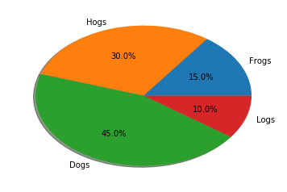

```python
import matplotlib.pyplot as plt
labels = 'Frogs', 'Hogs', 'Dogs', 'Logs'
fracs = [15, 30, 45, 10]
plt.pie(fracs, labels=labels, autopct='%1.1f%%', shadow=True)
plt.show()
```

# Also there are bar charts

- Another way to show data is with a bar chart.
- Here's an example, this time you have to give a integer position to the different values you're tallying.

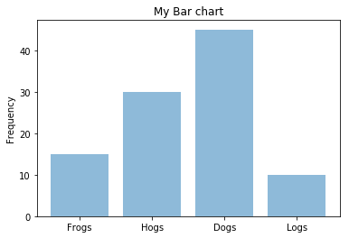

```python
labels = 'Frogs', 'Hogs', 'Dogs', 'Logs'
x_pos = range(len(labels))
fracs = [15, 30, 45, 10]
plt.bar(x_pos, fracs, align='center', alpha=0.5)
plt.xticks(x_pos, labels)
plt.ylabel('Frequency')
plt.title('My Bar chart')
plt.show()
```

# In the next session

- In the next session we're going to work on a project of our choosing.
- In these cases it is best download your own interactive developer environment (IDE).
- You can choose between [anaconda](https://www.anaconda.com/) or [thonny](https://thonny.org/).
- Thonny is a bit easier for beginners but anaconda may be better if you'll be coding a lot.
- Choose and download one of these before tomorrow's session begins.